# Path-dependent option pricing with Monte Carlo and Rcpp package

Applied Finance - Report

Szymon Socha

2022-12-13

# Description

The scope of this project was to create Rcpp package to simulate path-dependent option pricing with Monte Carlo method. I consider a European style **up-and-out call option** with a barrier active between the moment of pricing and the option expiry. The goal of the project was to study how individual variables affect option pricing. Included in the report are analyses of how the option price is affected by the value of the barrier level, volatility rate and time to maturity. In addition, the relationship of how simultaneously both factors (volatility rate and time to maturity) affect option pricing is analyzed.

**Theory**  
A condition of the European up-and-out call option is that it is canceled when, at any time during its term, the option price exceeds the level of a set barrier. In order for this option to make a profit for the holder, the price of the asset should be higher than the strike price on the redemption date. When the option price is lower than the strike price, the holder is not profitable to exercise the option and its value is then 0. The profit for the holder of a European up-and-out call option is therefore the difference between the final price between the price on the redemption date and the strike price (assuming that in none of the previous periods the price has exceeded the barrier and the difference between its price and the strike price is greater than zero).

# Simulations

## Install the `EUoutCalloptionPricer` package and load libraries

The source code of the package is pushed to private repository on `github.com`. To install the package from a private repository, I created a special authorization token. I did this in order to hide my solutions from other students (according to *Honor Code*). To access the raw code of the package, please contact me.

I use here `renv` package (**knitting may take a while!**). Alternatively, in order to install the package please use the following command:

**`devtools::install_github("szymonsocha/monte-carlo-option-pricing/package/EUoutCalloptionPricer", auth_token = "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")`**

## Find proper value of Barrier level

The function can take any user-specified parameters for: number of price changes, price of the underyling at the moment of option pricing, strike price, barrier level, annualized volatility rate, annualized risk-free rate, time to maturity and number of iterations in Monte Carlo simulation.

However, for the purposes of this report (according to the guidelines), the default function values are as follows:

- price of the underyling at the moment of option pricing: **S<sub>0</sub> = 95**
- strike price **K = 100**
- annualized volatility rate **σ = 0.24**
- annualized risk-free rate **r = 0.07**
- time to maturity **t = 0.75**

The default number of Monte Carlo simulation iterations is 1000 (**nReps = 1000**).

In order to determine the optimal value of the barrier level, I simulate the value of the option depending on its value.

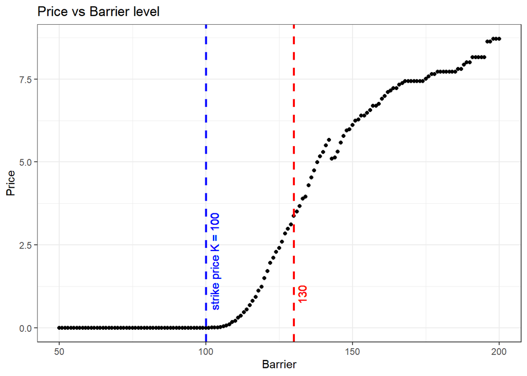

For the purposes of the report, I choose a barrier level value of **b = 130**. This is a purely arbitrary choice.

## Volatility rate simulation

In the next step, I look at how change in volatility rate affects the option price.

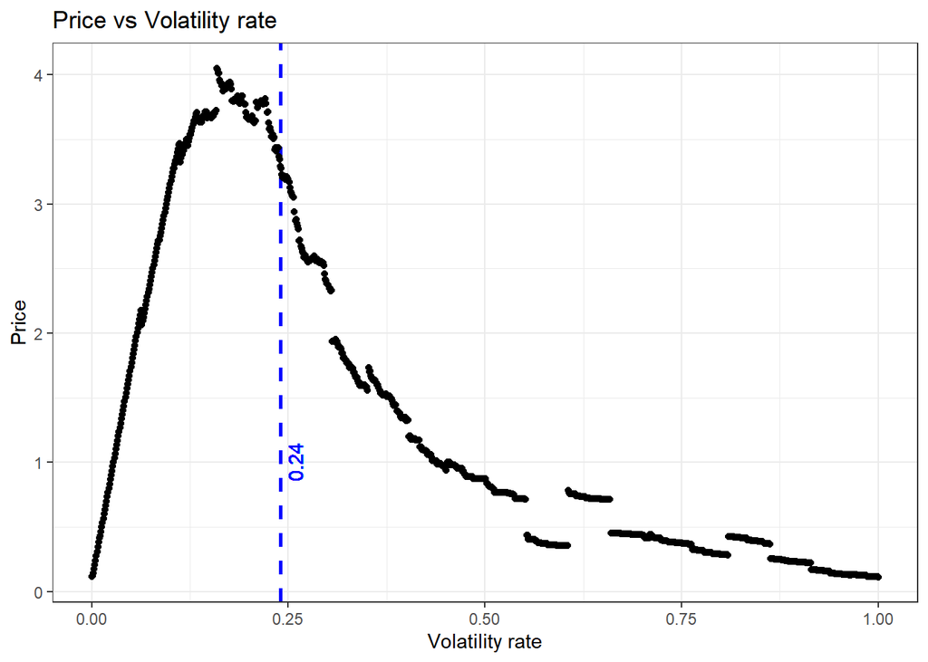

It can be observed that for small and sufficiently large values of volatility rate, the option price is low. This is because the high volatility of the asset causes the chance of ‘hitting’ the right price range (above strike price and below barrier level) to decrease. The blue vertical line indicates the value indicated in the task instructions.

## Time to Maturity simulation

In the next step, I check how the change in time to maturity affects the option price.

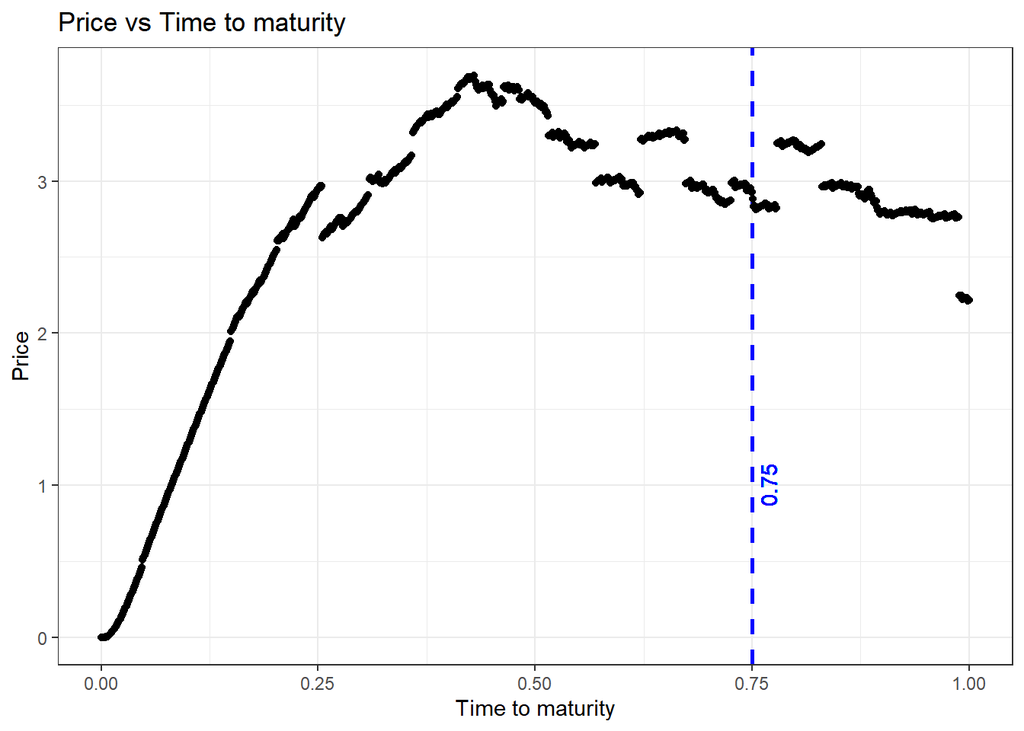

## Simultanious simulation

Finally, I analyze how a simultaneous change in volatility rate and time to maturity affects the option price.

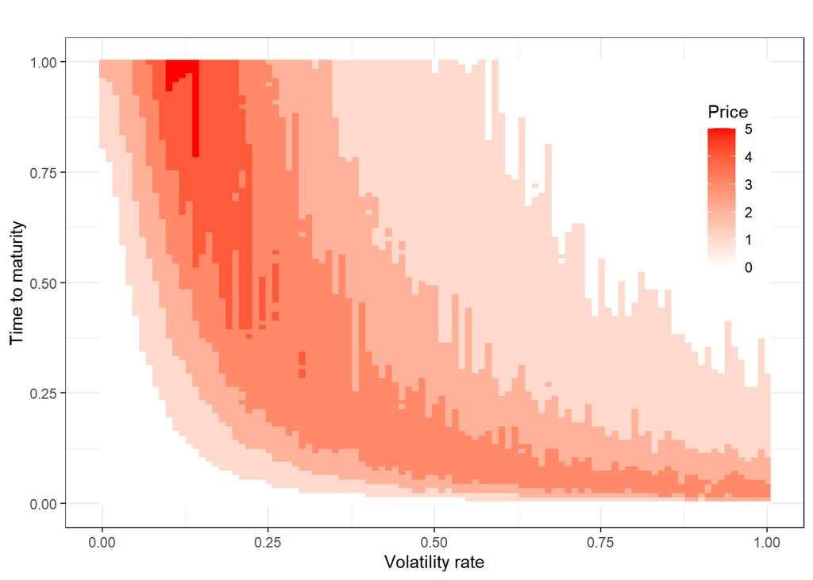

The results obtained are in line with those obtained earlier from a separate analysis of the two variables. A tradeoff between volatility rate and time to maturity is noted. The lower the value of the volatility rate, in order to maintain a high option price, it is necessary to increase the time to maturity. Conversely, the greater the value of the volatility rate, the smaller the time to maturity should be (in order to maintain a high option price).

This can be explained as follows. With high volatility in the price of the asset, the time to maturity should be as early as possible so that the price does not have time to change too much. Looking from the side of time to maturity, to keep the option price high, volatility rate should be relatively low.

# Results

The goal of the project was to build an Rcpp package, test it and draw conclusions on how the various option parameters affect its pricing. It was found that too low and too high volatility rates negatively affect option pricing. Similar conclusions were noted for the time to maturity rate. However, in this case, the sensitivity of option valuation to a change in the time to maturity rate was not as great. Finally, the relation between the theoretical price of the option and two factors (simultaneously) was analyzed. It confirmed earlier observations and observed a tradeoff between volatility rate and time to maturity due to option pricing.

*In accordance with the Honor Code, I certify that my answers here are my own work, and I did not make my solutions available to anyone else.*